# Title

## Familiarizing with NumPy, Pandas, and Matplotlib

# Aim

To learn the basics of NumPy, Pandas, and Matplotlib libraries in Python for numerical computation, data manipulation, and data visualization.

# Aim

To learn the basics of NumPy, Pandas, and Matplotlib libraries in Python for numerical computation, data manipulation, and data visualization.

# Objectives

- To create and manipulate 1-D and 2-D arrays using NumPy.
- To perform indexing, slicing, and searching operations on arrays.
- To calculate statistical measures such as mean, median, mode, variance, standard deviation, MSE, and RMSE.
- To create and manipulate DataFrames using Pandas.
- To import datasets and analyze them using Pandas functions.
- To visualize data using different plots in Matplotlib.

# Theory

## NumPy

NumPy is a Python library used for numerical and scientific computations. It provides support for large multidimensional arrays and matrices along with various mathematical functions to operate on them efficiently.

### Features of NumPy

- Fast array processing
- Multidimensional array support
- Mathematical and statistical functions
- Memory efficient operations

## Pandas

Pandas is a Python library used for data analysis and manipulation. It provides two major data structures:

- Series
- DataFrame

### Features of Pandas

- Easy data handling
- Data cleaning and filtering
- CSV file handling
- Statistical analysis tools

## Matplotlib

Matplotlib is a visualization library in Python used to create graphs and plots.

### Types of Graphs

- Line Plot
- Scatter Plot
- Bar Graph
- Pie Chart

# Software Requirements

- Python
- Jupyter Notebook / Google Colab
- NumPy
- Pandas
- Matplotlib

### 1. Creating 1-D and 2-D Arrays Using NumPy

```python
import numpy as np

arr1 = np.array([1, 2, 3, 4, 5])
print("1-D Array:")
print(arr1)

arr2 = arr1.reshape(1, 5)
print("Reshaped 2-D Array:")
print(arr2)

arr3 = np.array([[1, 2], [3, 4]])
arr4 = np.array([[5, 6], [7, 8]])

sum_array = arr3 + arr4

print("Addition of Arrays:")
print(sum_array)

print("Shape of arr3:")
print(arr3.shape)
```

```
1-D Array:
[1 2 3 4 5]
Reshaped 2-D Array:
[[1 2 3 4 5]]
Addition of Arrays:
[[ 6  8]
 [10 12]]
Shape of arr3:
(2, 2)
```

### 2. Accessing the Last Element of a 2-D Array

```python
print(arr3[-1, -1])
```

```
4
```

### 3. Array Slicing

```python
print(arr1[1:4])

print(arr3[:, 1])

print(arr1[::-1])
```

```
[2 3 4]
[2 4]
[5 4 3 2 1]
```

### 4. Searching Data Using where() and searchsorted()

```python
data = np.array([10, 20, 30, 40, 50])

x = np.where(data == 30)
print(x)

y = np.searchsorted(data, 35)
print(y)
```

```
(array([2]),)
3
```

### 5. Statistical Calculations

```python
from statistics import mode
import numpy as np

data = np.array([10, 20, 30, 40, 50])

mean = np.mean(data)
median = np.median(data)
mode_value = mode(data)
std = np.std(data)
variance = np.var(data)

print("Mean:", mean)
print("Median:", median)
print("Mode:", mode_value)
print("Standard Deviation:", std)
print("Variance:", variance)

actual = np.array([10, 20, 30])
predicted = np.array([12, 18, 33])

mse = np.mean((actual - predicted) ** 2)
rmse = np.sqrt(mse)

print("MSE:", mse)
print("RMSE:", rmse)
```

```
Mean: 30.0
Median: 30.0
Mode: 10
Standard Deviation: 14.142135623730951
Variance: 200.0
MSE: 5.666666666666667
RMSE: 2.3804761428476167
```

```python
import pandas as pd

data = {
    "Name": ["Ram", "Shyam", "Hari"],
    "Marks": [80, 75, 90]
}

df = pd.DataFrame(data)

print(df)
```

```
    Name  Marks
0    Ram     80
1  Shyam     75
2   Hari     90
```

### 7. Importing Dataset Using read_csv()

```python
# Import dataset from a CSV file
df = pd.read_csv('student_data.csv')

# Display the first few rows
print(df.head())

# Display basic information about the dataset
print(df.info())

# Display statistical summary
print(df.describe())
```

```
   ID   Name  Age  Marks
0   1  Aarav   20     85
1   2   Sita   21     90
2   3    Ram   22     88
3   4   Gita   20     76
4   5  Nabin   23     92
<class 'pandas.DataFrame'>
RangeIndex: 5 entries, 0 to 4
Data columns (total 4 columns):
 #   Column  Non-Null Count  Dtype
---  ------  --------------  -----
 0   ID      5 non-null      int64
 1   Name    5 non-null      str
 2   Age     5 non-null      int64
 3   Marks   5 non-null      int64
dtypes: int64(3), str(1)
memory usage: 292.0 bytes
None
             ID       Age     Marks
count  5.000000   5.00000   5.00000
mean   3.000000  21.20000  86.20000
std    1.581139   1.30384   6.26099
min    1.000000  20.00000  76.00000
25%    2.000000  20.00000  85.00000
50%    3.000000  21.00000  88.00000
75%    4.000000  22.00000  90.00000
max    5.000000  23.00000  92.00000
```

### 8. Adding New Columns in DataFrame

```python
df["Grade"] = ["A", "B", "A", "B", "A"]
print(df)
```

```
   ID   Name  Age  Marks Grade
0   1  Aarav   20     85     A
1   2   Sita   21     90     B
2   3    Ram   22     88     A
3   4   Gita   20     76     B
4   5  Nabin   23     92     A
```

### 9. Data Visualization Using Matplotlib

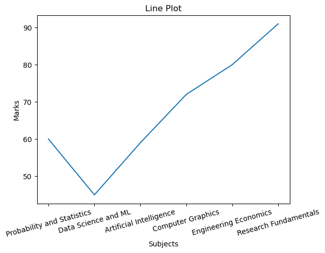

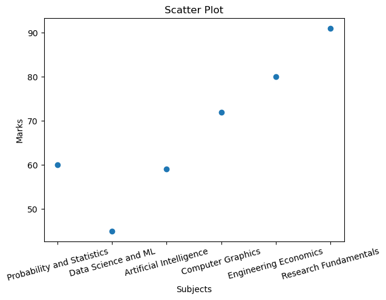

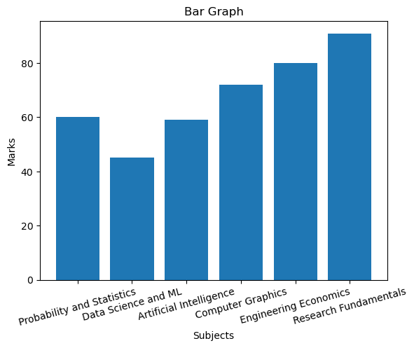

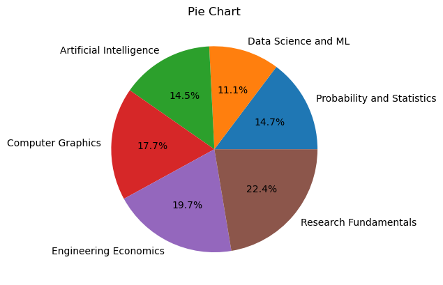

```python
import matplotlib.pyplot as plt

subjects = [
    "Probability and Statistics",
    "Data Science and ML",
    "Artificial Intelligence",
    "Computer Graphics",
    "Engineering Economics",
    "Research Fundamentals"
]

marks = [60, 45, 59, 72, 80, 91]

# Line Plot
plt.plot(subjects, marks)
plt.xlabel("Subjects")
plt.ylabel("Marks")
plt.title("Line Plot")
plt.xticks(rotation=15)
plt.show()

# Scatter Plot
plt.scatter(subjects, marks)
plt.xlabel("Subjects")
plt.ylabel("Marks")
plt.title("Scatter Plot")
plt.xticks(rotation=15)
plt.show()

# Bar Graph
plt.bar(subjects, marks)
plt.xlabel("Subjects")
plt.ylabel("Marks")
plt.title("Bar Graph")
plt.xticks(rotation=15)
plt.show()

# Pie Chart
plt.pie(marks, labels=subjects, autopct='%1.1f%%')
plt.title("Pie Chart")
plt.show()
```

# Result

The lab was completed successfully. Arrays and DataFrames were created and manipulated using NumPy and Pandas. Statistical calculations were performed, and different plots were generated using Matplotlib.

# Conclusion

This lab helped in understanding the fundamentals of NumPy, Pandas, and Matplotlib libraries. It provided practical knowledge of array manipulation, statistical analysis, data handling, and graphical visualization in Python, which are essential concepts in Data Science and Machine Learning.